# R for Beginners - R Code File -2

# Built in DATA Sets

The default R environment - comes bundled with a number of packages and data sets.

A package called DATASETS - contains a number of inbuilt data sets as seen in sections below -

```r
# Code Section -20

library(help = "datasets")


#
# Seen below are the DataSets available within my installed version of R -
# yours may slightly differ :-
#
# AirPassengers           Monthly Airline Passenger Numbers 1949-1960
# BJsales                 Sales Data with Leading Indicator
# BOD                     Biochemical Oxygen Demand
# CO2                     Carbon Dioxide Uptake in Grass Plants
# ChickWeight             Weight versus age of chicks on different diets
# DNase                   Elisa assay of DNase
# EuStockMarkets          Daily Closing Prices of Major European Stock
#                         Indices, 1991-1998
# Formaldehyde            Determination of Formaldehyde
# HairEyeColor            Hair and Eye Color of Statistics Students
# Harman23.cor            Harman Example 2.3
# Harman74.cor            Harman Example 7.4
# Indometh                Pharmacokinetics of Indomethacin
# InsectSprays            Effectiveness of Insect Sprays
# JohnsonJohnson          Quarterly Earnings per Johnson & Johnson Share
# LakeHuron               Level of Lake Huron 1875-1972
# LifeCycleSavings        Intercountry Life-Cycle Savings Data
# Loblolly                Growth of Loblolly pine trees
# Nile                    Flow of the River Nile
# Orange                  Growth of Orange Trees
# OrchardSprays           Potency of Orchard Sprays
# PlantGrowth             Results from an Experiment on Plant Growth
# Puromycin               Reaction Velocity of an Enzymatic Reaction
# Theoph                  Pharmacokinetics of Theophylline
# Titanic                 Survival of passengers on the Titanic
# ToothGrowth             The Effect of Vitamin C on Tooth Growth in
#                         Guinea Pigs
# UCBAdmissions           Student Admissions at UC Berkeley
# UKDriverDeaths          Road Casualties in Great Britain 1969-84
# UKLungDeaths            Monthly Deaths from Lung Diseases in the UK
# UKgas                   UK Quarterly Gas Consumption
# USAccDeaths             Accidental Deaths in the US 1973-1978
# USArrests               Violent Crime Rates by US State
# USJudgeRatings          Lawyers' Ratings of State Judges in the US
#                         Superior Court
# USPersonalExpenditure   Personal Expenditure Data
# VADeaths                Death Rates in Virginia (1940)
# WWWusage                Internet Usage per Minute
# WorldPhones             The World's Telephones
# ability.cov             Ability and Intelligence Tests
# airmiles                Passenger Miles on Commercial US Airlines,
#                         1937-1960
# airquality              New York Air Quality Measurements
# anscombe                Anscombe's Quartet of 'Identical' Simple Linear
#                         Regressions
# attenu                  The Joyner-Boore Attenuation Data
# attitude                The Chatterjee-Price Attitude Data
# austres                 Quarterly Time Series of the Number of
#                         Australian Residents
# beavers                 Body Temperature Series of Two Beavers
# cars                    Speed and Stopping Distances of Cars
# chickwts                Chicken Weights by Feed Type
# co2                     Mauna Loa Atmospheric CO2 Concentration
# crimtab                 Student's 3000 Criminals Data
# datasets-package        The R Datasets Package
# discoveries             Yearly Numbers of Important Discoveries
# esoph                   Smoking, Alcohol and (O)esophageal Cancer
# euro                    Conversion Rates of Euro Currencies
# eurodist                Distances Between European Cities and Between
#                         US Cities
# faithful                Old Faithful Geyser Data
# freeny                  Freeny's Revenue Data
# infert                  Infertility after Spontaneous and Induced
#                         Abortion
# iris                    Edgar Anderson's Iris Data
# islands                 Areas of the World's Major Landmasses
# lh                      Luteinizing Hormone in Blood Samples
# longley                 Longley's Economic Regression Data
# lynx                    Annual Canadian Lynx trappings 1821-1934
# morley                  Michelson Speed of Light Data
# mtcars                  Motor Trend Car Road Tests
# nhtemp                  Average Yearly Temperatures in New Haven
# nottem                  Average Monthly Temperatures at Nottingham,
#                         1920-1939
# npk                     Classical N, P, K Factorial Experiment
# occupationalStatus      Occupational Status of Fathers and their Sons
# precip                  Annual Precipitation in US Cities
# presidents              Quarterly Approval Ratings of US Presidents
# pressure                Vapor Pressure of Mercury as a Function of
#                         Temperature
# quakes                  Locations of Earthquakes off Fiji
# randu                   Random Numbers from Congruential Generator
#                         RANDU
# rivers                  Lengths of Major North American Rivers
# rock                    Measurements on Petroleum Rock Samples
# sleep                   Student's Sleep Data
# stackloss               Brownlee's Stack Loss Plant Data
# state                   US State Facts and Figures
# sunspot.month           Monthly Sunspot Data, from 1749 to "Present"
# sunspot.year            Yearly Sunspot Data, 1700-1988
# sunspots                Monthly Sunspot Numbers, 1749-1983
# swiss                   Swiss Fertility and Socioeconomic Indicators
#                         (1888) Data
# treering                Yearly Treering Data, -6000-1979
# trees                   Girth, Height and Volume for Black Cherry Trees
# uspop                   Populations Recorded by the US Census
# volcano                 Topographic Information on Auckland's Maunga
#                         Whau Volcano
# warpbreaks              The Number of Breaks in Yarn during Weaving
# women                   Average Heights and Weights for American Women
#
```

# ATTACH and DETACH Datasets

To OPERATE upon an inbuilt DATASET we need to LOAD it into R .

In lay-man terms , we may equate this to our earlier - read.csv() , but

there are subtle differences.

The ATTACH will pull in a Data Set from the DataSet Package into our R Search Path.

```r
# Code Section -21

?attach()

# # Quoting below from inbuilt HELP -
# # The database is attached to the R search path. This means that the database is
# searched by R when evaluating a variable, so objects in the database can be accessed
# by simply giving their names.

?detach()

# # Quoting below from inbuilt HELP -
# # Detach a database, i.e., remove it from the search() path of available R objects.
# Usually this is either a data.frame which has been attached or a
# package which was attached by library.

# Another Function which will help automate is - zap()

# library(epicalc)
# ?zap()
# https://artax.karlin.mff.cuni.cz/r-help/library/epicalc/html/zap.html
```

```r
# Code Section -22

search()
```

```
## [1] ".GlobalEnv"        "package:stats"     "package:graphics"
## [4] "package:grDevices" "package:utils"     "package:datasets"
## [7] "package:methods"   "Autoloads"         "package:base"
```

# DATA_FRAME COLUMNS - The DF Column Vector

```r
# Code Section -23

# Three basic methods to access a DF COLUMN - also called the
# DF Column Vector

print(df_1[[2]]) # Will Print 2nd COLUMN of the DF
```

```
##  [1] OFF-LA-10002782 FUR-FU-10004015 FUR-BO-10002352 OFF-BI-10004428
##  [5] OFF-AR-10004594 OFF-EN-10001375 OFF-EN-10001375 TEC-MA-10004956
##  [9] OFF-SU-10003474 TEC-AC-10001830 OFF-BI-10002075 OFF-FA-10002526
## [13] FUR-CH-10002846 OFF-EN-10004100 OFF-AR-10003914 OFF-FA-10000038
## [17] OFF-EN-10000761 FUR-FU-10003066 OFF-EN-10000075 OFF-EN-10002226
## [21] FUR-CH-10002132 TEC-AC-10002749 OFF-SU-10000066 OFF-BI-10003934
## [25] OFF-BI-10003932
## 24 Levels: FUR-BO-10002352 FUR-CH-10002132 ... TEC-MA-10004956
```

```r
#
print(df_1[["Product.Name"]]) # Will Print the "NAMED"  COLUMN of the DF
```

```
##  [1] OFF-LA-10002782 FUR-FU-10004015 FUR-BO-10002352 OFF-BI-10004428
##  [5] OFF-AR-10004594 OFF-EN-10001375 OFF-EN-10001375 TEC-MA-10004956
##  [9] OFF-SU-10003474 TEC-AC-10001830 OFF-BI-10002075 OFF-FA-10002526
## [13] FUR-CH-10002846 OFF-EN-10004100 OFF-AR-10003914 OFF-FA-10000038
## [17] OFF-EN-10000761 FUR-FU-10003066 OFF-EN-10000075 OFF-EN-10002226
## [21] FUR-CH-10002132 TEC-AC-10002749 OFF-SU-10000066 OFF-BI-10003934
## [25] OFF-BI-10003932
## 24 Levels: FUR-BO-10002352 FUR-CH-10002132 ... TEC-MA-10004956
```

```r
#
print(df_1$Product.Name) # Will Print the "NAMED" COLUMN of the DF
```

```
##  [1] OFF-LA-10002782 FUR-FU-10004015 FUR-BO-10002352 OFF-BI-10004428
##  [5] OFF-AR-10004594 OFF-EN-10001375 OFF-EN-10001375 TEC-MA-10004956
##  [9] OFF-SU-10003474 TEC-AC-10001830 OFF-BI-10002075 OFF-FA-10002526
## [13] FUR-CH-10002846 OFF-EN-10004100 OFF-AR-10003914 OFF-FA-10000038
## [17] OFF-EN-10000761 FUR-FU-10003066 OFF-EN-10000075 OFF-EN-10002226
## [21] FUR-CH-10002132 TEC-AC-10002749 OFF-SU-10000066 OFF-BI-10003934
## [25] OFF-BI-10003932
## 24 Levels: FUR-BO-10002352 FUR-CH-10002132 ... TEC-MA-10004956
```

# DATA_FRAME - Row and Column Slices

```r
# Code Section -24

# Slicing the DF COLUMNS and ROWS

print(df_1[2]) # Will Print 2nd COLUMN - ALL ROWS - of the DF as a SLICE.
```

```
##       Product.Name
## 1  OFF-LA-10002782
## 2  FUR-FU-10004015
## 3  FUR-BO-10002352
## 4  OFF-BI-10004428
## 5  OFF-AR-10004594
## 6  OFF-EN-10001375
## 7  OFF-EN-10001375
## 8  TEC-MA-10004956
## 9  OFF-SU-10003474
## 10 TEC-AC-10001830
## 11 OFF-BI-10002075
## 12 OFF-FA-10002526
## 13 FUR-CH-10002846
## 14 OFF-EN-10004100
## 15 OFF-AR-10003914
## 16 OFF-FA-10000038
## 17 OFF-EN-10000761
## 18 FUR-FU-10003066
## 19 OFF-EN-10000075
## 20 OFF-EN-10002226
## 21 FUR-CH-10002132
## 22 TEC-AC-10002749
## 23 OFF-SU-10000066
## 24 OFF-BI-10003934
## 25 OFF-BI-10003932
```

```r
#
print(df_1[2,]) # Will Print 2nd ROW - ALL COLUMNS - of the DF as a SLICE.
```

```
##   X.    Product.Name        Prod.ID Date.of.Invoice Date.of.Shipping
## 2  2 FUR-FU-10004015 MX-2012-155047      01-01-2013       02-01-2013
##   Cost.Price Quantity Sales.Price Shipping.Index Shipping.Type  Category
## 2     252.16        8     2017.28              2      PRIORITY Furniture
```

```r
#
df_temp1 <- (df_1[2,])
df_temp1
```

```
##   X.    Product.Name        Prod.ID Date.of.Invoice Date.of.Shipping
## 2  2 FUR-FU-10004015 MX-2012-155047      01-01-2013       02-01-2013
##   Cost.Price Quantity Sales.Price Shipping.Index Shipping.Type  Category
## 2     252.16        8     2017.28              2      PRIORITY Furniture
```

```r
View(df_temp1)
#
summary(df_temp1)
```

```
##        X.             Product.Name           Prod.ID    Date.of.Invoice
##  Min.   :2   FUR-FU-10004015:1     MX-2012-155047:1   01-01-2013:1
##  1st Qu.:2   FUR-BO-10002352:0     MX-2013-134096:0   02-01-2013:0
##  Median :2   FUR-CH-10002132:0     MX-2013-156335:0
##  Mean   :2   FUR-CH-10002846:0     MX-2013-163139:0
##  3rd Qu.:2   FUR-FU-10003066:0     MX-2013-167759:0
##  Max.   :2   OFF-AR-10003914:0     MX-2014-121923:0
##              (Other)        :0     (Other)       :0
##    Date.of.Shipping   Cost.Price       Quantity  Sales.Price
##  02-01-2013:1       Min.   :252.2   Min.   :8   Min.   :2017
##  03-01-2013:0       1st Qu.:252.2   1st Qu.:8   1st Qu.:2017
##  04-01-2013:0       Median :252.2   Median :8   Median :2017
##                     Mean   :252.2   Mean   :8   Mean   :2017
##                     3rd Qu.:252.2   3rd Qu.:8   3rd Qu.:2017
##                     Max.   :252.2   Max.   :8   Max.   :2017
##
##  Shipping.Index  Shipping.Type            Category
##  Min.   :2      PRIORITY:1     Furniture      :1
##  1st Qu.:2      STANDARD:0     Office Supplies:0
##  Median :2                     Technology     :0
##  Mean   :2
##  3rd Qu.:2
##  Max.   :2
##
```

```r
print(df_1[c(2,4,6)]) # Using an INDEX VECTOR  - created with COMBINE Function.
```

```
##       Product.Name Date.of.Invoice Cost.Price
## 1  OFF-LA-10002782      01-01-2013     13.080
## 2  FUR-FU-10004015      01-01-2013    252.160
## 3  FUR-BO-10002352      01-01-2013    193.280
## 4  OFF-BI-10004428      01-01-2013     35.440
## 5  OFF-AR-10004594      01-01-2013     71.600
## 6  OFF-EN-10001375      01-01-2013     56.120
## 7  OFF-EN-10001375      01-01-2013     56.120
## 8  TEC-MA-10004956      01-01-2013    344.640
## 9  OFF-SU-10003474      01-01-2013     97.360
## 10 TEC-AC-10001830      01-01-2013    341.520
## 11 OFF-BI-10002075      01-01-2013     12.060
## 12 OFF-FA-10002526      01-01-2013     20.760
## 13 FUR-CH-10002846      01-01-2013    210.640
## 14 OFF-EN-10004100      02-01-2013     80.100
## 15 OFF-AR-10003914      02-01-2013    132.640
## 16 OFF-FA-10000038      02-01-2013     12.940
## 17 OFF-EN-10000761      02-01-2013     18.840
## 18 FUR-FU-10003066      02-01-2013    308.280
## 19 OFF-EN-10000075      02-01-2013     40.176
## 20 OFF-EN-10002226      02-01-2013      8.784
## 21 FUR-CH-10002132      02-01-2013    273.472
## 22 TEC-AC-10002749      02-01-2013     27.000
## 23 OFF-SU-10000066      02-01-2013    207.000
## 24 OFF-BI-10003934      02-01-2013     60.660
## 25 OFF-BI-10003932      02-01-2013    181.116
```

```r
# To access MULTIPLE COLUMNS - 2,4 and 6 of the DF.
```

Lets create a New Directory - Files Folder from within R and house our basic introductory graphs there - we use - dir.create()

```r
# Code Section -25

#dir.create("/home/dhankar/Desktop/R_Own/Plots/Intro_2/", recursive=TRUE) # to be RUN only Once
```

# Plots and Graphs - the Basics

Over the next couple of sections we shall preview the basics of Plots and Graphs.

If we were to execute the code from the following sections , in the Console- the Graphs would not appear inline but would appear within the PLOTS pane of R Studio or in certain cases as POP Up’s.

# HISTOGRAM an Introduction

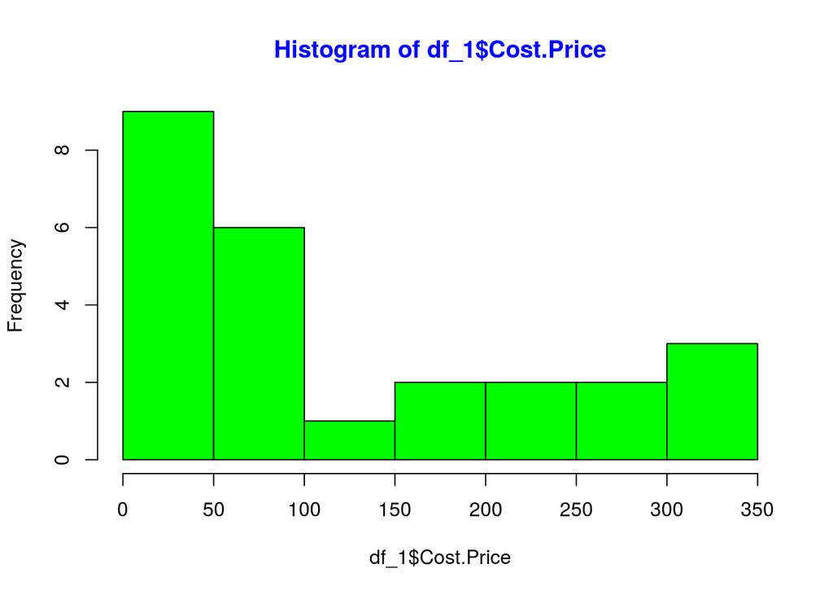

```r
# Code Section -26
# So what exactly is a HISTOGRAM -
# " estimate of the probability distribution of a continuous variable (quantitative variable)"
# Source -- Wiki -- https://en.wikipedia.org/wiki/Histogram


hist(df_1$Cost.Price,col.main="blue",col = "green")
```

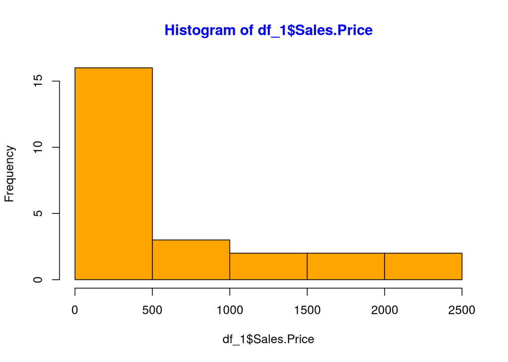

```r
#
hist(df_1$Sales.Price,col.main="blue",col = "orange")
```

# par() Function - Multiple adjacent plots

par{graphics}

Next sections we look at some basic usage of the par() function , with it we can create a matrix of nrows X ncolumns - of various plots and graphs

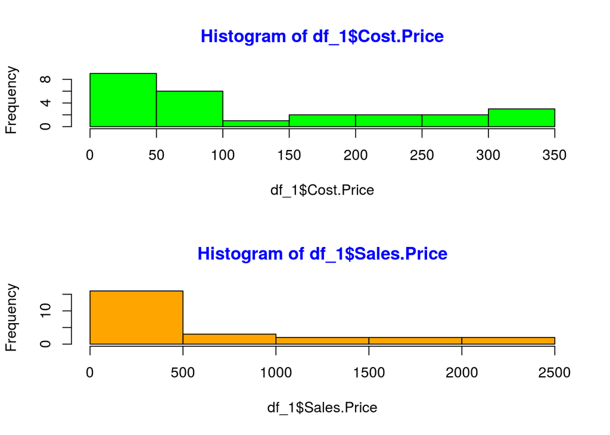

```r
# Code Section -27
#?par() # Uncomment for Help

opar <- par(no.readonly=TRUE)
par(mfrow=c(2,1)) # 2 - ROWS , 1 - COLUMN - Filled in by ROWS # or we may use - mfcol=c() , to fill by COLUMNS
hist(df_1$Cost.Price,col.main="blue",col = "green")
hist(df_1$Sales.Price,col.main="blue",col = "orange")
```

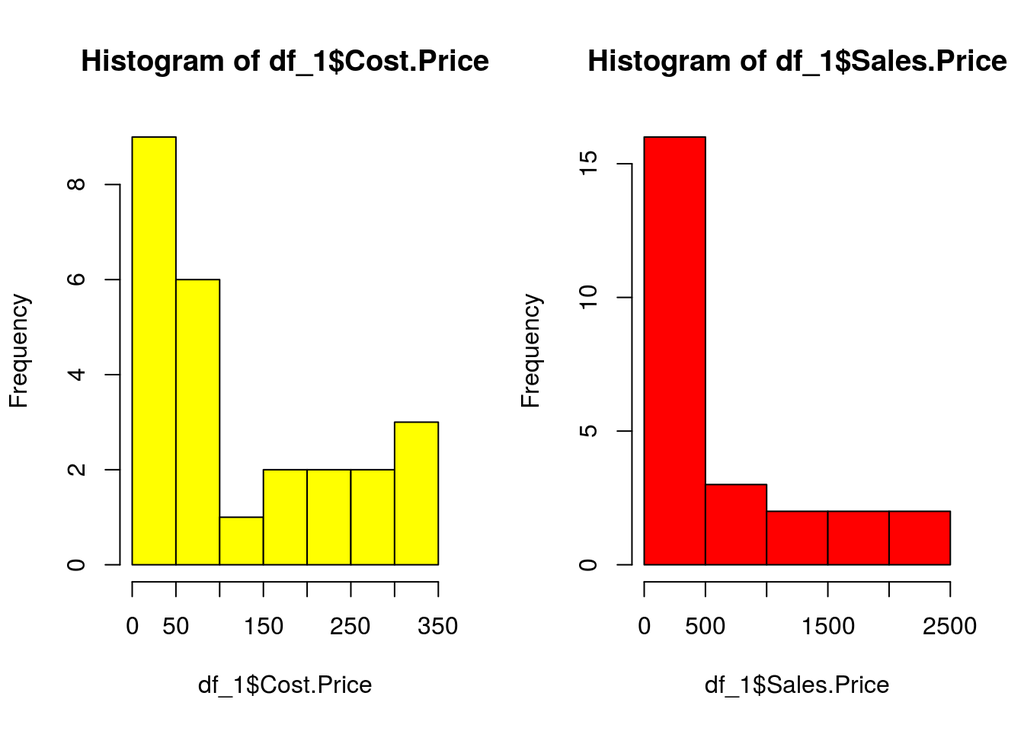

```r
# Next lets try - sub-plot in 2 COLUMNS and 1 ROW

opar <- par(no.readonly=TRUE)
par(mfrow=c(1,2)) # 1 - ROW , 2 - COLUMNS
hist(df_1$Cost.Price,col.main="black",col = "yellow")
hist(df_1$Sales.Price,col.main="black",col = "red")
```

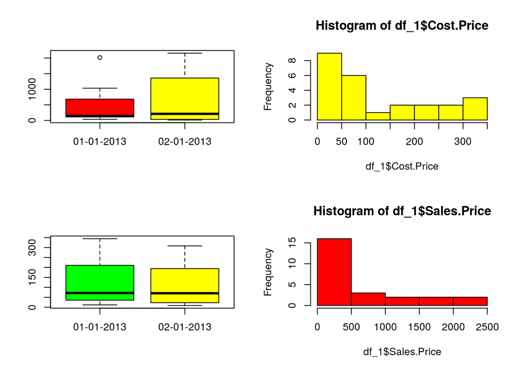

```r
#
opar <- par(no.readonly=TRUE)
par(mfrow=c(2,2)) # 2 - ROWS , 2 - COLUMNS
plot(df_1$Date.of.Invoice,df_1$Sales.Price,col=c("red","yellow"))
hist(df_1$Cost.Price,col.main="black",col = "yellow")
plot(df_1$Date.of.Invoice,df_1$Cost.Price,col=c("green","yellow"))
hist(df_1$Sales.Price,col.main="black",col = "red")
```

# LAYOUT of Plots - beyond the par()

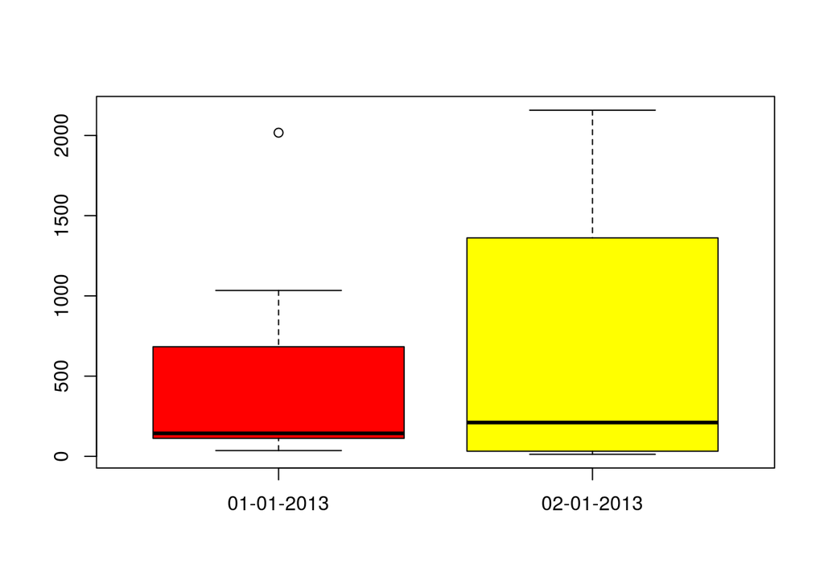

```r
# Code Section -28
## The same set of PLOTS as earlier now formatted
# with Layout inplace of par()


#?layout()

layout(matrix(1, 2, byrow = TRUE),widths = c(4,1),heights = c(4,1))

plot(df_1$Date.of.Invoice,df_1$Sales.Price,col=c("red","yellow"))
```

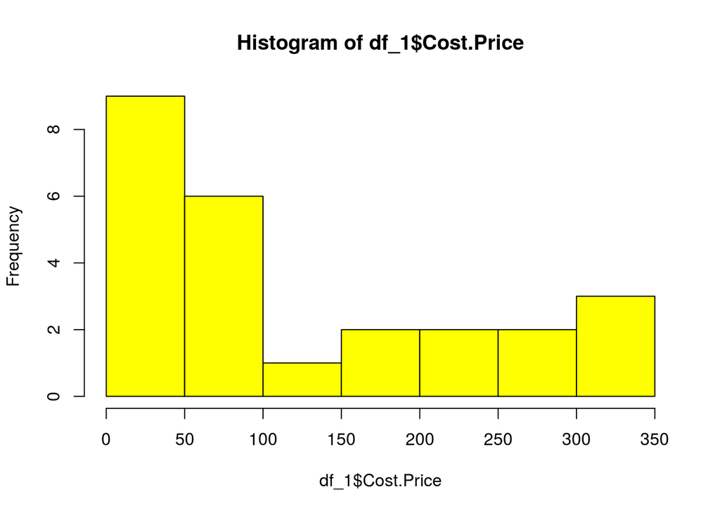

```r
#
hist(df_1$Cost.Price,col.main="black",col = "yellow")
```

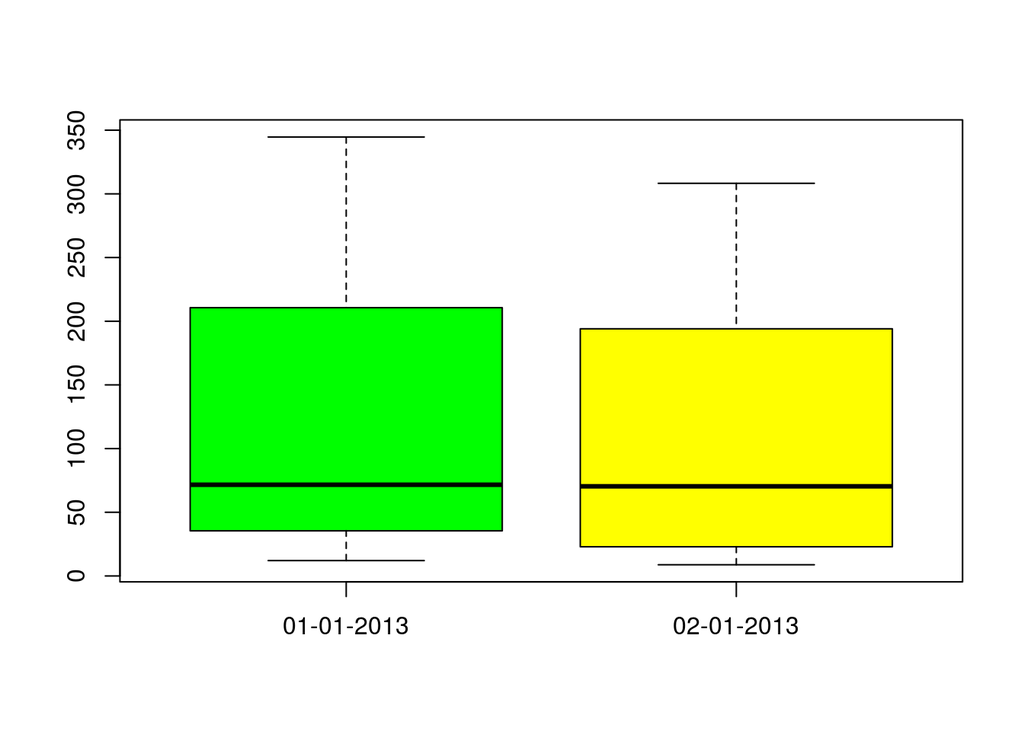

```r
#
plot(df_1$Date.of.Invoice,df_1$Cost.Price,col=c("green","yellow"))
```

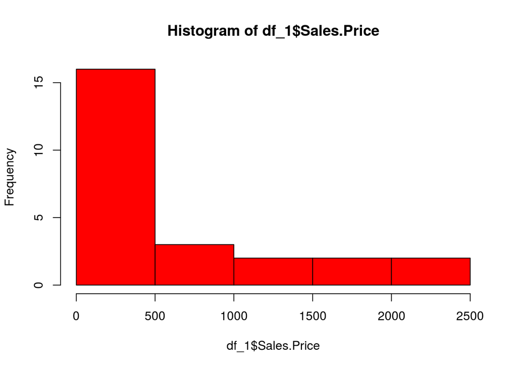

```r
#
hist(df_1$Sales.Price,col.main="black",col = "red")
```

# SCATTER Plot - initial Intro

```r
# Code Section -29

df_a1 <- read.csv("~/Desktop/R_Own/Data_Directory/mcprod.csv")
#
summary(df_a1)
```

```
##        X            a1             a2              a3
##  Prod_1 : 1   Min.   :10.4   Min.   :4.000   Min.   : 71.1
##  Prod_10: 1   1st Qu.:15.2   1st Qu.:4.000   1st Qu.:120.3
##  Prod_11: 1   Median :19.2   Median :6.000   Median :196.3
##  Prod_12: 1   Mean   :20.3   Mean   :6.158   Mean   :229.8
##  Prod_13: 1   3rd Qu.:24.0   3rd Qu.:8.000   3rd Qu.:342.0
##  Prod_14: 1   Max.   :33.9   Max.   :8.000   Max.   :472.0
##  (Other):32
##        a4              a5              a6              a7
##  Min.   : 52.0   Min.   :2.760   Min.   :1.513   Min.   :14.50
##  1st Qu.: 95.5   1st Qu.:3.098   1st Qu.:2.356   1st Qu.:16.88
##  Median :123.0   Median :3.715   Median :3.325   Median :17.41
##  Mean   :145.6   Mean   :3.614   Mean   :3.149   Mean   :17.72
##  3rd Qu.:180.0   3rd Qu.:3.920   3rd Qu.:3.690   3rd Qu.:18.83
##  Max.   :335.0   Max.   :4.930   Max.   :5.424   Max.   :22.90
##
##        a8               a9              a10             a11
##  Min.   :0.0000   Min.   :0.0000   Min.   :3.000   Min.   :1.000
##  1st Qu.:0.0000   1st Qu.:0.0000   1st Qu.:3.000   1st Qu.:2.000
##  Median :0.0000   Median :0.0000   Median :3.500   Median :2.000
##  Mean   :0.4211   Mean   :0.4211   Mean   :3.711   Mean   :2.684
##  3rd Qu.:1.0000   3rd Qu.:1.0000   3rd Qu.:4.000   3rd Qu.:4.000
##  Max.   :1.0000   Max.   :1.0000   Max.   :5.000   Max.   :8.000
##
```

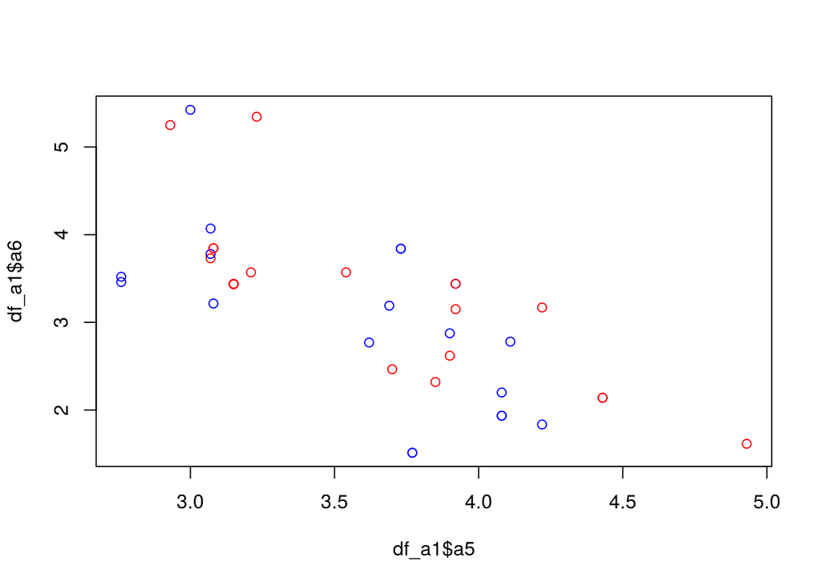

```r
#
plot(df_a1$a5,df_a1$a6,col=c("red","blue"))
```

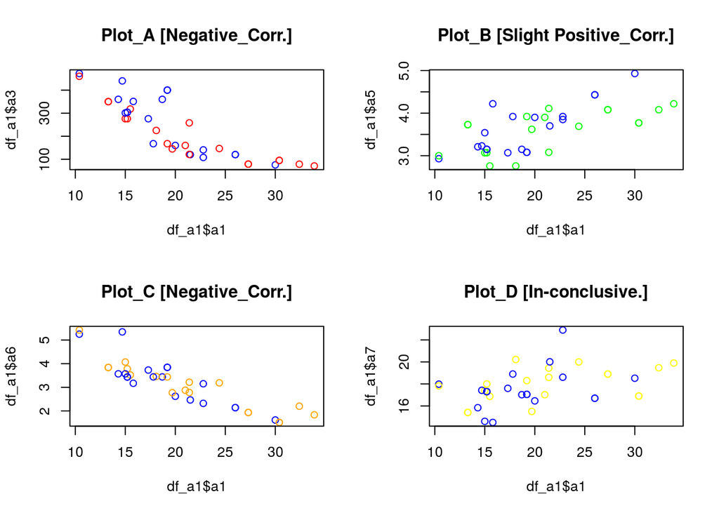

```r
#
# Its a Synthetic Simulated Dataset for learning purposes ...
# As seen below - Variables a1,a3,a5-a7 == Double / Decimal
# (Double Precision Numeric Values)
# X1 == Var Char
# All others are Integers

# QUOTING Verbatim - WIKI-Scatter Diagram -- https://en.wikipedia.org/wiki/Scatter_plot
#
# If no dependent variable exists, either type of variable can be plotted
# on either axis and a scatter plot will illustrate only the
# degree of correlation (not causation) between two variables.
#
# VERY VERY VERY Important - NOT CAUSATION ... so how do we
# ascertain CAUSATION , we shall see within this text soon.

# Again we plot multiple plots within a PLOT MATRIX using par()
opar <- par(no.readonly=TRUE)
par(mfrow=c(2,2)) # 2 - ROWS , 2 - COLUMNS
#
plot(df_a1$a1,df_a1$a3,col=c("blue","red"),main="Plot_A [Negative_Corr.]")
#
plot(df_a1$a1,df_a1$a5,col=c("blue","green"),main="Plot_B [Slight Positive_Corr.]")
#
plot(df_a1$a1,df_a1$a6,col=c("blue","orange"),main="Plot_C [Negative_Corr.]")
#
plot(df_a1$a1,df_a1$a7,col=c("blue","yellow"),main="Plot_D [In-conclusive.]")
```

```r
#
```

Looking at these FOUR Scatter Plots we can now have a basic level discussion about - CORRELATION amongst different variables in any given Data Set.

We have chosen to have - variable “a1” on the X Axis of all Four Plots .

Plot_A - Var “a1” and “a3” seem to be Highly Correlated . As values of “a1” increase the values of “a3” decrease.

Plot_C - Var “a1” and “a6” seem to be Highly Correlated . As values of “a1” increase the values of “a6” decrease.

Plot_D - We are not able to draw any inference for Correlation.

```r
# Code Section -30
```

```r
# Code Section -32
```

```r
# Code Section -33
```

```r
# Code Section -34
```

```r
# Code Section -35
```

```r
# Code Section -36
```